# Praca domowa 2

Paweł Zakrzewski

## Dane

Dane wykorzystane w Pracy domowej 2 dotyczą wyników egzaminów z 3 umiejętności: czytania, pisania i operacji matematycznych. Dodatkowo dostępne są podstawowe informacje o studentach i ich rodzicach. Opis wszystkich kolumn znajduje się również w pliku `README.md`.

| Zmienna | Opis |
| --- | --- |
| **gender** | płeć |
| **race.ethnicity** | pochodzenie etniczne |
| **parental.level.of.education** | wykształcenie rodziców |
| **lunch** | jaki obiad jedli uczniowie w dniu egzaminu |
| **test.preparation.course** | czy uczeń odbył kurs przygotowujący |
| **math.score** | wynik egzaminu z matematyki |
| **reading.score** | wynik egzaminu z czytania |
| **writing.score** | wynik egzaminu z pisania |

## Zadanie 1

Jak wyglądają rozkłady wyników uczniów z trzech przedmiotów (matematyka, czytanie, pisanie)?

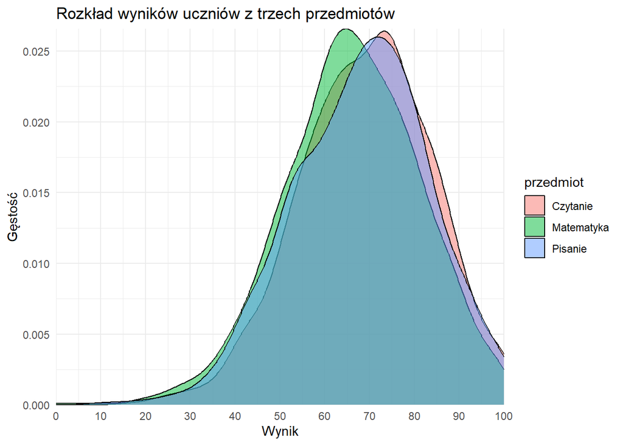

```r
# Tu umieść kod do wygenerowania odpowiedzi do zadania.
df_1 <- pivot_longer(df, cols=c("math.score", "reading.score", "writing.score"), names_to="przedmiot", values_to="wynik") %>%
  mutate(przedmiot = recode(przedmiot,
                           "math.score" = "Matematyka",
                           "reading.score" = "Czytanie",
                           "writing.score" = "Pisanie"))

ggplot(data = df_1, mapping=aes(x=wynik, fill=przedmiot)) +
  geom_density(alpha=0.5) +
  labs(x = "Wynik", y="Gęstość", title="Rozkład wyników uczniów z trzech przedmiotów") +
  scale_x_continuous(breaks=seq(0,100, by=10), expand=c(0,0)) +
  scale_y_continuous(expand=c(0,0)) +
  theme_minimal()
```

**Komentarz:** Widać, że wyniki z czytania i pisania są do siebie dosyć podobne, gdzie najwięcej wyników mamy w okolicach 73%. Wyniki z matematyki jednak są zauważalnie niższe, gdzie najwięcej wyników otrzymaliśmy w okolicach 65%.

## Zadanie 2

Czy istnieje zauważalna różnica w wynikach między uczniami i uczennicami?

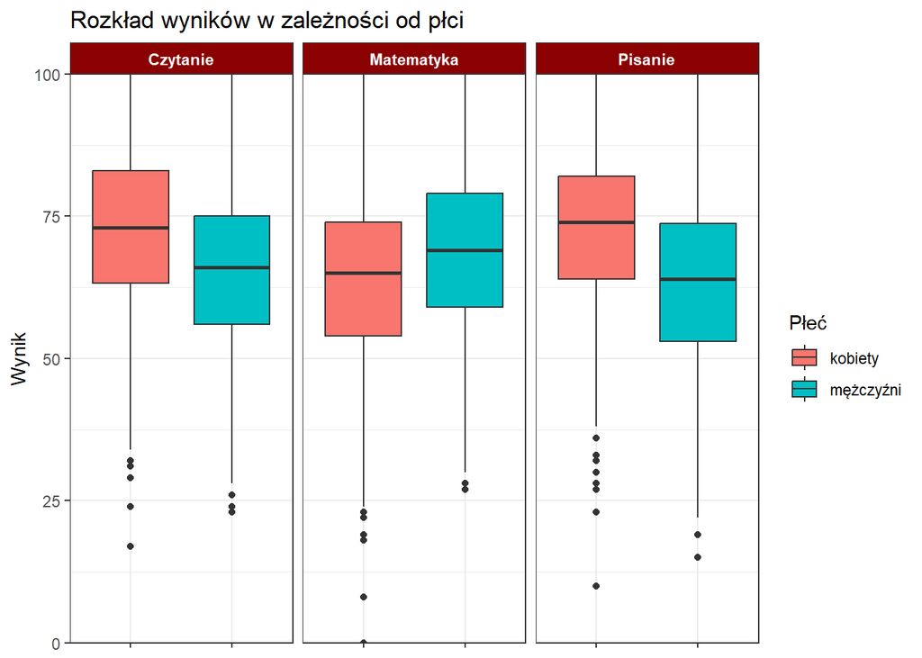

```r
df_2 <- df %>%
  select(gender,math.score,writing.score,reading.score) %>%
  pivot_longer(cols=c(math.score, writing.score, reading.score),
               names_to="Subject", values_to="Score") %>%
  mutate(Subject = recode(Subject,
                           "math.score" = "Matematyka",
                           "reading.score" = "Czytanie",
                           "writing.score" = "Pisanie"),
         gender = recode(gender, "female"= "kobiety", "male" = "mężczyźni"))

ggplot(df_2, aes(x=gender,y=Score,fill=gender)) +
  geom_boxplot() +
  facet_wrap(~ Subject) +
  labs(title = "Rozkład wyników w zależności od płci", x="Płeć", y="Wynik", fill="Płeć") +
  scale_y_continuous(expand=c(0,0)) +
  theme_bw() +
  theme(axis.text.x = element_blank(), axis.title.x = element_blank(),
        strip.background=element_rect(fill="darkred"),
        strip.text=element_text(color="white", face="bold"))
```

**Komentarz:** Na podstawie wykresów możemy zauważyć, że kobiety radzą sobie nieco lepiej w czytaniu i pisaniu, za to mężczyźni osiągają lekko lepsze wyniki w matematyce. Nie są to bardzo duże, aczkolwiek zauważalne różnice.